신록예찬's 블로그

# (5주차) 10월12일 (수정중)

Oct 12, 2021 • 최규빈 • 4 min read

- 강의영상
- MSEloss 와 BCEloss 비교
  - 손실함수의 모양비교
  - 아키텍처, 옵티마이저
  - 초기값 $(w_0,w_1)=(-3,-1)$을 대입하고 수렴과정을 애니메이션으로 확인해보자.
  - 초기값 $(w_0,w_1)=(-10,-1)$을 대입하고 수렴과정을 애니메이션으로 확인해보자.
  - 초기값 $(w_0,w_1)=(-3,-1)$로 다시변경, 에폭 100회로 변경, 옵티마이저를 ADAM으로 변경
  - 초기값 $(w_0,w_1)=(-10,-1)$, 에폭100회로 변경, 옵티마이저를 ADAM으로 변경

## 강의영상

[video not shown]

`-` (1/8) 손실함수 (1)

`-` (2/8) 손실함수 (2)

`-` (3/8) 손실함수차이를 애니메이션으로

`-` (4/8) Adam

`-` (5/8) Adam animation

`-` (6/8) 신경망은 왜 깊어졌는가?,universal approximation theorem

`-` (7/8) MNIST with MLP 풀이1

`-` (8/8) MNIST with MLP 풀이2,3

## MSEloss 와 BCEloss 비교

#### 손실함수의 모양비교

```python
import numpy as np
```

```python
torch.manual_seed(1)
X=torch.linspace(-1,1,2000).reshape(2000,1)
w0= -1
w1= 5
u=X*w1+w0
v=torch.exp(u)/(1+(torch.exp(u)))
y=torch.bernoulli(v)
```

```python
import pandas as pd
```

```python
_w0 = np.arange(-10, 3, 0.05)
_w1 = np.arange(-1, 10, 0.05)
_w0,_w1 = np.meshgrid(_w0,_w1,indexing='ij')
```

```python
_w0=_w0.reshape(-1)
_w1=_w1.reshape(-1)
```

```python
def lossfn_crossenp(w0,w1):
    yhat= torch.exp(w0+w1*X)/(1+torch.exp(w0+w1*X))
    loss=- torch.mean((y*torch.log(yhat) + (1-y)*torch.log(1-yhat)))
    return loss.tolist()
def lossfn_mse(w0,w1):
    yhat= torch.exp(w0+w1*X)/(1+torch.exp(w0+w1*X))
    loss=torch.mean((y-yhat)**2)
    return loss.tolist()
```

```python
_l1=list(map(lossfn_crossenp,_w0,_w1))
_l2=list(map(lossfn_mse,_w0,_w1))
```

[figure not shown]

```python
fig = plt.figure()
ax1= fig.add_subplot(1,2,1,projection='3d')
ax2= fig.add_subplot(1,2,2,projection='3d')
ax1.elev = 15
ax2.elev = 15
ax1.azim = 75
ax2.azim = 75
fig.set_figheight(15)
fig.set_figwidth(15)
```

```python
_w0[np.argmin(_l1)],_w1[np.argmin(_l1)]
```

```
(-0.9999999999998721, 5.150000000000006)
```

```python
lossfn_crossenp(_w0[np.argmin(_l1)],_w1[np.argmin(_l1)])
```

```
0.30768516659736633
```

```python
_l1[np.argmin(_l1)]
```

```
0.30768516659736633
```

```python
np.min(_l1)
```

```
0.30768516659736633
```

```python
_w0[np.argmin(_l2)],_w1[np.argmin(_l2)]
```

```
(-0.9999999999998721, 5.100000000000005)
```

```python
ax1.scatter(_w0,_w1,_l1,s=0.01)
ax2.scatter(_w0,_w1,_l2,s=0.01)
ax1.scatter(-1,5,lossfn_crossenp(-1,5),s=200,color='red',marker='*')
ax1.scatter(_w0[np.argmin(_l1)],_w1[np.argmin(_l1)],lossfn_crossenp(_w0[np.argmin(_l1)],_w1[np.argmin(_l1)]),s=200,color='red',marker='x')
ax2.scatter(-1,5,lossfn_mse(-1,5),s=200,color='red',marker='*')
ax2.scatter(_w0[np.argmin(_l2)],_w1[np.argmin(_l2)],lossfn_mse(_w0[np.argmin(_l2)],_w1[np.argmin(_l2)]),s=200,color='red',marker='x')
```

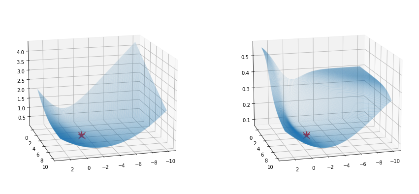

```python
fig
```

#### 아키텍처, 옵티마이저

```python
l1=torch.nn.Linear(in_features=1,out_features=1,bias=True)
a1=torch.nn.Sigmoid()
net=torch.nn.Sequential(l1,a1)
optimizer=torch.optim.SGD(net.parameters(),lr=0.05)
```

#### 초기값 $(w_0,w_1)=(-3,-1)$을 대입하고 수렴과정을 애니메이션으로 확인해보자.

`-` 파라메터초기값 $(w_0,w_1)=(-3,-1)$로 설정

```python
l1.bias.data,l1.weight.data
```

```
(tensor([0.0331]), tensor([[-0.1853]]))
```

```python
l1.bias.data=torch.tensor([-3.0])
l1.weight.data=torch.tensor([[-1.0]])
```

```python
l1.bias.data,l1.weight.data
```

```
(tensor([-3.]), tensor([[-1.]]))
```

`-` MSEloss를 사용하여 학습 + 기록

```python
loss_mse=[]
w0_mse=[]
w1_mse=[]
for epoc in range(1000):
    ## 1
    yhat=net(X)
    ## 2
    loss=torch.mean((y-yhat)**2)
    ## 3
    loss.backward()
    ## 4
    optimizer.step()
    net.zero_grad()
    ## 5 record
    if epoc%20==0:
        w0_mse.append(l1.bias.data.item())
        w1_mse.append(l1.weight.data.item())
        loss_mse.append(loss.item())
```

```python
l1.bias.data,l1.weight.data
```

```
(tensor([-0.9688]), tensor([[0.7116]]))
```

```python
l1.bias.data=torch.tensor([-3.0])
l1.weight.data=torch.tensor([[-1.0]])
```

```python
l1.bias.data,l1.weight.data
```

```
(tensor([-3.]), tensor([[-1.]]))
```

`-` BCEloss를 이용하여 학습 + 기록

```python
loss_bce=[]
w0_bce=[]
w1_bce=[]
for epoc in range(1000):
    ## 1
    yhat=net(X)
    ## 2
    loss= - torch.mean((y*torch.log(yhat) + (1-y)*torch.log(1-yhat)))
    ## 3
    loss.backward()
    ## 4
    optimizer.step()
    net.zero_grad()
    ## 5 record
    if epoc%20==0:
        w0_bce.append(l1.bias.data.item())
        w1_bce.append(l1.weight.data.item())
        loss_bce.append(loss.item())
```

```python
l1.bias.data,l1.weight.data
```

```
(tensor([-0.6726]), tensor([[3.3696]]))
```

`-` plot

```python
from matplotlib import animation
from IPython.display import HTML
plt.rcParams["animation.html"] = "jshtml"
### figsetting
fig = plt.figure()
ax1= fig.add_subplot(2,2,1,projection='3d')
ax2= fig.add_subplot(2,2,2,projection='3d')
ax3= fig.add_subplot(2,2,3)
ax4= fig.add_subplot(2,2,4)
ax1.elev = 15
ax2.elev = 15
ax1.azim = 75
ax2.azim = 75
fig.set_figheight(15)
fig.set_figwidth(15)

### init plot
ax1.scatter(_w0,_w1,_l1,s=0.05)
ax2.scatter(_w0,_w1,_l2,s=0.05)
ax1.scatter(-3,-1,lossfn_crossenp(-3,-1),color='gray')
ax1.scatter(-1,5,lossfn_crossenp(-1,5),s=200,color='red',marker='*')
#ax1.scatter(_w0[np.argmin(_l1)],_w1[np.argmin(_l1)],loss_crossenp(_w0[np.argmin(_l1)],_w1[np.argmin(_l1)]),s=200,color='red',marker='x')
ax2.scatter(-3,-1,lossfn_mse(-3,-1),color='gray')
ax2.scatter(-1,5,lossfn_mse(-1,5),s=200,color='red',marker='*')
#ax2.scatter(_w0[np.argmin(_l2)],_w1[np.argmin(_l2)],loss_mse(_w0[np.argmin(_l2)],_w1[np.argmin(_l2)]),s=200,color='red',marker='x')
ax3.scatter(X,y,alpha=0.01)
ax3.plot(X,v,'--')
line3, = ax3.plot(X,1/(1+torch.exp(-w0_bce[0]-w1_bce[0]*X)),'--')
ax4.scatter(X,y,alpha=0.01)
ax4.plot(X,v,'--')
line4, = ax4.plot(X,1/(1+torch.exp(-w0_mse[0]-w1_mse[0]*X)),'--')


### animation
def animate(i):
    ax1.scatter(w0_bce[i],w1_bce[i],lossfn_crossenp(w0_bce[i],w1_bce[i]),color='gray')
    ax2.scatter(w0_mse[i],w1_mse[i],lossfn_mse(w0_mse[i],w1_mse[i]),color='gray')
    line3.set_ydata(1/(1+torch.exp(-w0_bce[i]-w1_bce[i]*X)))
    line4.set_ydata(1/(1+torch.exp(-w0_mse[i]-w1_mse[i]*X)))
    return line3,line4

ani = animation.FuncAnimation(fig, animate, frames=50)
plt.close()
ani
```

#### 초기값 $(w_0,w_1)=(-10,-1)$을 대입하고 수렴과정을 애니메이션으로 확인해보자.

`-` 파라메터초기값 $(w_0,w_1)=(-10,-1)$로 설정

```python
l1.bias.data=torch.tensor([-10.0])
l1.weight.data=torch.tensor([[-1.0]])
```

`-` BCEloss를 이용하여 학습 + 기록

```python
loss_bce=[]
w0_bce=[]
w1_bce=[]
for epoc in range(1000):
    ## 1
    yhat=net(X)
    ## 2
    loss= - torch.mean((y*torch.log(yhat) + (1-y)*torch.log(1-yhat)))
    ## 3
    loss.backward()
    ## 4
    optimizer.step()
    net.zero_grad()
    ## 5 record
    if epoc%20==0:
        w0_bce.append(l1.bias.data.item())
        w1_bce.append(l1.weight.data.item())
        loss_bce.append(loss.item())
```

```python
l1.bias.data,l1.weight.data
```

`-` 파라메터초기값 $(w_0,w_1)=(-10,-1)$로 다시 설정

```python
l1.bias.data=torch.tensor([-10.0])
l1.weight.data=torch.tensor([[-1.0]])
```

`-` MSEloss를 사용하여 학습 + 기록

```python
loss_mse=[]
w0_mse=[]
w1_mse=[]
for epoc in range(1000):
    ## 1
    yhat=net(X)
    ## 2
    loss=torch.mean((y-yhat)**2)
    ## 3
    loss.backward()
    ## 4
    optimizer.step()
    net.zero_grad()
    ## 5 record
    if epoc%20==0:
        w0_mse.append(l1.bias.data.item())
        w1_mse.append(l1.weight.data.item())
        loss_mse.append(loss.item())
```

`-` plot

```python
from matplotlib import animation
from IPython.display import HTML
plt.rcParams["animation.html"] = "jshtml"
### figsetting
fig = plt.figure()
ax1= fig.add_subplot(2,2,1,projection='3d')
ax2= fig.add_subplot(2,2,2,projection='3d')
ax3= fig.add_subplot(2,2,3)
ax4= fig.add_subplot(2,2,4)
ax1.elev = 15
ax2.elev = 15
ax1.azim = 75
ax2.azim = 75
fig.set_figheight(15)
fig.set_figwidth(15)

### init plot
ax1.scatter(_w0,_w1,_l1,s=0.05)
ax2.scatter(_w0,_w1,_l2,s=0.05)
ax1.scatter(-10,-1,lossfn_crossenp(-10,-1),color='gray')
ax1.scatter(-1,5,lossfn_crossenp(-1,5),s=200,color='red',marker='*')
ax2.scatter(-10,-1,lossfn_mse(-10,-1),color='gray')
ax2.scatter(-1,5,lossfn_mse(-1,5),s=200,color='red',marker='*')
ax3.scatter(X,y,alpha=0.01)
ax3.plot(X,v,'--')
line3, = ax3.plot(X,1/(1+torch.exp(-w0_bce[0]-w1_bce[0]*X)),'--')
ax4.scatter(X,y,alpha=0.01)
ax4.plot(X,v,'--')
line4, = ax4.plot(X,1/(1+torch.exp(-w0_mse[0]-w1_mse[0]*X)),'--')


### animation
def animate(i):
    ax1.scatter(w0_bce[i],w1_bce[i],lossfn_crossenp(w0_bce[i],w1_bce[i]),color='gray')
    ax2.scatter(w0_mse[i],w1_mse[i],lossfn_mse(w0_mse[i],w1_mse[i]),color='gray')
    line3.set_ydata(1/(1+torch.exp(-w0_bce[i]-w1_bce[i]*X)))
    line4.set_ydata(1/(1+torch.exp(-w0_mse[i]-w1_mse[i]*X)))
    return line3,line4

ani = animation.FuncAnimation(fig, animate, frames=50)
plt.close()
ani
```

#### 초기값 $(w_0,w_1)=(-3,-1)$로 다시변경, 에폭 100회로 변경, 옵티마이저를 ADAM으로 변경

`-` 옵티마이저 재설정

```python
optimizer=torch.optim.Adam(net.parameters(),lr=0.05)
```

`-` 파라메터초기값 $(w_0,w_1)=(-3,-1)$로 설정

```python
l1.bias.data,l1.weight.data
```

```python
l1.bias.data=torch.tensor([-3.0])
l1.weight.data=torch.tensor([[-1.0]])
```

```python
l1.bias.data,l1.weight.data
```

`-` BCEloss를 이용하여 학습 + 기록

```python
loss_bce=[]
w0_bce=[]
w1_bce=[]
for epoc in range(100):
    ## 1
    yhat=net(X)
    ## 2
    loss= - torch.mean((y*torch.log(yhat) + (1-y)*torch.log(1-yhat)))
    ## 3
    loss.backward()
    ## 4
    optimizer.step()
    net.zero_grad()
    ## 5 record
    if epoc%2==0:
        w0_bce.append(l1.bias.data.item())
        w1_bce.append(l1.weight.data.item())
        loss_bce.append(loss.item())
        print(l1.bias.data.item(),l1.weight.data.item())
```

```python
l1.bias.data,l1.weight.data
```

`-` 파라메터초기값 $(w_0,w_1)=(-3,-1)$로 설정

```python
l1.bias.data,l1.weight.data
```

```python
l1.bias.data=torch.tensor([-3.0])
l1.weight.data=torch.tensor([[-1.0]])
```

```python
l1.bias.data,l1.weight.data
```

`-` MSEloss를 사용하여 학습 + 기록

```python
loss_mse=[]
w0_mse=[]
w1_mse=[]
for epoc in range(100):
    ## 1
    yhat=net(X)
    ## 2
    loss=torch.mean((y-yhat)**2)
    ## 3
    loss.backward()
    ## 4
    optimizer.step()
    net.zero_grad()
    ## 5 record
    if epoc%2==0:
        w0_mse.append(l1.bias.data.item())
        w1_mse.append(l1.weight.data.item())
        loss_mse.append(loss.item())
```

`-` plot

```python
from matplotlib import animation
from IPython.display import HTML
plt.rcParams["animation.html"] = "jshtml"
### figsetting
fig = plt.figure()
ax1= fig.add_subplot(2,2,1,projection='3d')
ax2= fig.add_subplot(2,2,2,projection='3d')
ax3= fig.add_subplot(2,2,3)
ax4= fig.add_subplot(2,2,4)
ax1.elev = 15
ax2.elev = 15
ax1.azim = 75
ax2.azim = 75
fig.set_figheight(15)
fig.set_figwidth(15)

### init plot
ax1.scatter(_w0,_w1,_l1,s=0.05)
ax2.scatter(_w0,_w1,_l2,s=0.05)
ax1.scatter(-3,-1,lossfn_crossenp(-3,-1),color='gray')
ax1.scatter(-1,5,lossfn_crossenp(-1,5),s=200,color='red',marker='*')
#ax1.scatter(_w0[np.argmin(_l1)],_w1[np.argmin(_l1)],loss_crossenp(_w0[np.argmin(_l1)],_w1[np.argmin(_l1)]),s=200,color='red',marker='x')
ax2.scatter(-3,-1,lossfn_mse(-3,-1),color='gray')
ax2.scatter(-1,5,lossfn_mse(-1,5),s=200,color='red',marker='*')
#ax2.scatter(_w0[np.argmin(_l2)],_w1[np.argmin(_l2)],loss_mse(_w0[np.argmin(_l2)],_w1[np.argmin(_l2)]),s=200,color='red',marker='x')
ax3.scatter(X,y,alpha=0.01)
ax3.plot(X,v,'--')
line3, = ax3.plot(X,1/(1+torch.exp(-w0_bce[0]-w1_bce[0]*X)),'--')
ax4.scatter(X,y,alpha=0.01)
ax4.plot(X,v,'--')
line4, = ax4.plot(X,1/(1+torch.exp(-w0_mse[0]-w1_mse[0]*X)),'--')


### animation
def animate(i):
    ax1.scatter(w0_bce[i],w1_bce[i],lossfn_crossenp(w0_bce[i],w1_bce[i]),color='gray')
    ax2.scatter(w0_mse[i],w1_mse[i],lossfn_mse(w0_mse[i],w1_mse[i]),color='gray')
    line3.set_ydata(1/(1+torch.exp(-w0_bce[i]-w1_bce[i]*X)))
    line4.set_ydata(1/(1+torch.exp(-w0_mse[i]-w1_mse[i]*X)))
    return line3,line4

ani = animation.FuncAnimation(fig, animate, frames=50)
plt.close()
ani
```

#### 초기값 $(w_0,w_1)=(-10,-1)$, 에폭100회로 변경, 옵티마이저를 ADAM으로 변경

`-` 옵티마이저 재설정

```python
optimizer=torch.optim.Adam(net.parameters(),lr=0.05)
```

```python
l1.bias.data,l1.weight.data
```

```python
l1.bias.data=torch.tensor([-10.0])
l1.weight.data=torch.tensor([[-1.0]])
```

```python
l1.bias.data,l1.weight.data
```

`-` MSEloss를 사용하여 학습 + 기록

```python
loss_mse=[]
w0_mse=[]
w1_mse=[]
for epoc in range(100):
    ## 1
    yhat=net(X)
    ## 2
    loss=torch.mean((y-yhat)**2)
    ## 3
    loss.backward()
    ## 4
    optimizer.step()
    net.zero_grad()
    ## 5 record
    if epoc%2==0:
        w0_mse.append(l1.bias.data.item())
        w1_mse.append(l1.weight.data.item())
        loss_mse.append(loss.item())
```

`-` 파라메터초기값 $(w_0,w_1)=(-10,-1)$로 설정

```python
l1.bias.data,l1.weight.data
```

```python
l1.bias.data=torch.tensor([-10.0])
l1.weight.data=torch.tensor([[-1.0]])
```

```python
l1.bias.data,l1.weight.data
```

`-` BCEloss를 이용하여 학습 + 기록

```python
loss_bce=[]
w0_bce=[]
w1_bce=[]
for epoc in range(100):
    ## 1
    yhat=net(X)
    ## 2
    loss= - torch.mean((y*torch.log(yhat) + (1-y)*torch.log(1-yhat)))
    ## 3
    loss.backward()
    ## 4
    optimizer.step()
    net.zero_grad()
    ## 5 record
    if epoc%2==0:
        w0_bce.append(l1.bias.data.item())
        w1_bce.append(l1.weight.data.item())
        loss_bce.append(loss.item())
```

```python
l1.bias.data,l1.weight.data
```

`-` plot

```python
from matplotlib import animation
from IPython.display import HTML
plt.rcParams["animation.html"] = "jshtml"
### figsetting
fig = plt.figure()
ax1= fig.add_subplot(2,2,1,projection='3d')
ax2= fig.add_subplot(2,2,2,projection='3d')
ax3= fig.add_subplot(2,2,3)
ax4= fig.add_subplot(2,2,4)
ax1.elev = 15
ax2.elev = 15
ax1.azim = 75
ax2.azim = 75
fig.set_figheight(15)
fig.set_figwidth(15)

### init plot
ax1.scatter(_w0,_w1,_l1,s=0.05)
ax2.scatter(_w0,_w1,_l2,s=0.05)
ax1.scatter(-10,-1,lossfn_crossenp(-10,-1),color='gray')
ax1.scatter(-1,5,lossfn_crossenp(-1,5),s=200,color='red',marker='*')
#ax1.scatter(_w0[np.argmin(_l1)],_w1[np.argmin(_l1)],loss_crossenp(_w0[np.argmin(_l1)],_w1[np.argmin(_l1)]),s=200,color='red',marker='x')
ax2.scatter(-10,-1,lossfn_mse(-10,-1),color='gray')
ax2.scatter(-1,5,lossfn_mse(-1,5),s=200,color='red',marker='*')
#ax2.scatter(_w0[np.argmin(_l2)],_w1[np.argmin(_l2)],loss_mse(_w0[np.argmin(_l2)],_w1[np.argmin(_l2)]),s=200,color='red',marker='x')
ax3.scatter(X,y,alpha=0.01)
ax3.plot(X,v,'--')
line3, = ax3.plot(X,1/(1+torch.exp(-w0_bce[0]-w1_bce[0]*X)),'--')
ax4.scatter(X,y,alpha=0.01)
ax4.plot(X,v,'--')
line4, = ax4.plot(X,1/(1+torch.exp(-w0_mse[0]-w1_mse[0]*X)),'--')


### animation
def animate(i):
    ax1.scatter(w0_bce[i],w1_bce[i],lossfn_crossenp(w0_bce[i],w1_bce[i]),color='gray')
    ax2.scatter(w0_mse[i],w1_mse[i],lossfn_mse(w0_mse[i],w1_mse[i]),color='gray')
    line3.set_ydata(1/(1+torch.exp(-w0_bce[i]-w1_bce[i]*X)))
    line4.set_ydata(1/(1+torch.exp(-w0_mse[i]-w1_mse[i]*X)))
    return line3,line4

ani = animation.FuncAnimation(fig, animate, frames=50)
plt.close()
ani
```